# Wang et al. 2015 Replication Report

Juan Miguel Arias

March 14, 2016

#### Replication of Study 2 in “Is Math Anxiety Always Bad for Math Learning? The Role of Math Motivation” by Wang, Z., Lukowski, S.L., Hart, S.A., Lyons, I.M., Thompson, L.A., Kovas, Y., Mazzocco, M.M., Plomin, R. & Petrill, S.A. (2015, Psychological Science)

*Replication author:* Juan Miguel Arias

*Course instructors:* Dr. Michael Frank, Robert Hawkins, & Eric Smith

*Contact information:* email: stanfordpsych254 (at) gmail (dot) com

*Testable replication experiment webpage:* https://web.stanford.edu/~jmarias/jmariasProject/experiment/254surveytask.html

*Link to original study (Wang et al., 2015) PDF:* http://pss.sagepub.com/content/early/2015/10/30/0956797615602471.full.pdf+html

### Introduction

The study presented here attempts to replicate the findings of Study 2 in Wang et al. (2015), which demonstrated that the relationship between math anxiety and math performance follows an inverted-U pattern among college undergraduate students with higher intrinsic math motivation, whereas this same relationship is linearly negative among students with lower intrinsic math motivation. The current study attempts to replicate this finding using Amazon Mechanical Turk participants.

### Method

#### Power Analysis

Original test: F-test: multiple, fixed-effects regression with 9 total predictors and one observed predictor for change in R-squared.

Original effect size:

- Of total R-squared: **.16**
- Of change in R-squared for variable of interest (interaction of math anxiety squared and math motivation): **.02**.

Power analysis for original study: For an effect size of .02 from the above F-test with 219 participants and an alpha of .05, the estimated power achieved of the original is: **55%**.

- Sample Size needed to achieve 80% power (assuming same effect size): **395**.
- Sample Size needed to achieve 90% power (assuming same effect size): **528**.
- Sample Size needed to achieve 95% power (assuming same effect size): **652**.

#### Planned Sample

To achieve 80% power, the planned sample will be **415** adult participants recruited from Amazon’s Mechanical Turk platform. This total number is calculated as 5% above the 395 participants needed, in order to satisfy the power calculation after potentially removing participants due to missing data or other exclusion criteria.

Study 2 of Wang et al. (2015) initially collected data from 237 undergraduate students, 56% female, mean age = 19.53 years old (*SD* = 2.01, range = 18 - 39), for their participant sample (219 participants were kept for the full analyses).

#### Materials

Please see below for quoted descriptions of the materials used in the original study, which were adapted for the present replication to be used by an online MTurk population:

> Participants self-reported math anxiety using the brief version of the Mathematics Anxiety Rating Scale (MARS-B; Suinn & Winston, 2003). The 30-item MARS-B is widely used to measure math anxiety in adults. Items are rated on a 5-point Likert-type scale (1 = not at all nervous, 5 = very very nervous). The MARS-B has excellent internal consistency (Cronbach’s alpha = .94).

> The trait subscale from the State-Trait Anxiety Inventory (Spielberger, 1983) was used to measure participants’ general anxiety. This subscale consists of 20 items that are rated on a 4-point Likert-type scale (1 = almost never, 4 = almost always). This scale has excellent internal consistency (Cronbach’s alpha = .94).

> Participants self-reported their math motivation using the same three items from the scale used in Study 1 (M. M. Chiu and Zeng, 2008). The Cronbach’s alpha for this scale is .82, which indicates good internal consistency.

> The problem-verification task (Rinne & Mazzocco, 2014) was used to measure participants’ math calculation fluency. Because the 64 easy items were far too easy for undergraduate students (mean accuracy = .93, SD = .06), we chose to focus on the 24 hard items (e.g., double-digit arithmetic, uncommon- denominator fraction, and solutions close to the correct answer). The hard items had wider performance variability (mean accuracy = .85, SD = .13) and were therefore a more proper measure of individual differences in calculation fluency in college students. On a laptop, participants were shown a series of two-operand arithmetic problems involving addition, subtraction, multiplication, division, and equivalency of fractions. For each arithmetic problem, a solution was shown that was correct or incorrect, and participants were asked to answer “right,” “wrong,” or “don’t know” as quickly as possible without calculating. Each item was presented for a maximum of 10 s. If no response was given within that time, the program proceeded to the next item. Reaction time (in seconds) was defined as the time between stimulus onset and response. For the current analyses, an efficiency score was calculated by dividing the percentage of total correct responses by the mean reaction time across all items.

### Procedure

#### Analysis Plan

Please see below for quoted descriptions of the relevant elements of the analysis plan from the original study, which were also conducted by the current replication. See below for differences of note between original and replication in the materials and procedure.

> Hierarchical regression analysis was used to examine whether the quadratic relation between math anxiety and math cognition was further moderated by math motivation. Specifically, performance on the problem- verification task was predicted in four steps. In Step 1, covariates including age, sex, and linear and quadratic terms of general anxiety were entered. The linear term of math motivation and math anxiety was entered in Step 2. In Step 3, we entered the quadratic term of math anxiety and the interaction between math anxiety and math motivation. Finally, we entered the moderated quadratic interaction term between math anxiety and math motivation in Step 4. Math anxiety, math motivation, and general anxiety were standardized and centered prior to analyses in order to compute the interaction and higher-order terms. The outcome variable was also standardized to maintain consistency across the two studies.

### *Replication differences from Original Study*

#### Differences in Materials/Procedure

- The three surveys and the measure of math performance (the Problem-Verification Task), were presented to participants as a webpage, direct from the MTurk interface, rather than as a Qualtrics survey, as in the original study (Study 2 of Wang et al., 2015).
- In the current replication, each survey question had to be answered in order to continue to the next question, whereas in the original study, the survey questions prompted the participant to answer if no answer was given but allowed participant to continue without answering if they selected to continue multiple times.

#### Differences in Analysis Plan

- No differences in the analysis plans between the original and replication are anticipated.
- We also include a correlation table of the relevant variables as as done in the original, although this was not explicitly specified in their analysis plan.

### Data preparation

Data preparation following the analysis plan.

```r
#Temporarily changing wd to see where the error files are located within the vector of files in the json folder - to comment out
#setwd("C:\\Users\\Juan\\Documents\\1. STANFORD\\2nd Year 15-16\\Psych254 Replication Methods\\Psych254 Project\\Psych254proj_mturk_DONTCOMMIT\\Arias 254 Full Replication\\production-results\\")
#dir()

#Reading the path
path <- "C:\\Users\\Juan\\Documents\\1. STANFORD\\2nd Year 15-16\\Psych254 Replication Methods\\Psych254 Project\\Psych254proj_mturk_DONTCOMMIT\\Arias 254 Full Replication\\"

files <- dir(paste0(path,"production-results\\"),
             pattern = "*.json")
d <- data.frame()

#Transforming data from JSON format to dataframe
#?fromJSON

#reading the json files and turning them into one data.frame
for (f in files) {
  jf <- paste0(path, "production-results\\",f)
  jd <- fromJSON(file = jf)                      #(paste(readLines(jf), collapse=""))
  id <- data.frame(workerid = jd$WorkerId,
                   accepttime = jd$AcceptTime,
                   submittime = jd$SubmitTime,
                   trial_number = jd$answers$data$trial_number,
                   block_number = jd$answers$data$block_number,
                   trial_type = jd$answers$data$trial_type,
                   stimulus = jd$answers$data$stimulus,
                   rating_raw = jd$answers$data$rating,
                   RT = as.numeric(jd$answers$data$rt),
                   age = jd$answers$data$age,  #age = as.numeric(jd$answers$data$age),
                   gender = jd$answers$data$gender,
                   education = jd$answers$data$education,
                          #education = as.factor(jd$answers$data$education),
                   student = jd$answers$data$student,
                   homelang = jd$answers$data$homelang,
                   ethnicity = jd$answers$data$ethnicity,
                             #student = as.factor(jd$answers$data$student),
                             #homelang = as.character(jd$answers$data$homelang),
                             #ethnicity = as.factor(jd$answers$data$ethnicity),
                   race = jd$answers$data$race,
                   children = jd$answers$data$children,
                   mathhwhelp = jd$answers$data$mathhwhelp,
                   childAgeOld = jd$answers$data$childAgeOld,
                   expt_aim = jd$answers$data$expt_aim,
                   expt_gen = jd$answers$data$expt_gen)
 d <- bind_rows(d, id)
}



#warnings()
#warnings()  ##(Commented out for now) -- shows lots of NAs introduced by coercion
#Number of participants
length(unique(d$workerid))
```

```
## [1] 403
```

```r
############ Prepping Survey Responses for Analyses ####################################

#Making age and gender numeric and factor variables, respectively
d$gender <- as.factor(d$gender)
d$age <- as.numeric(d$age)
d$education <- as.factor(d$education)
d$student <- as.factor(d$student)
d$homelang <- as.character(d$homelang)
d$ethnicity <- as.factor(d$ethnicity)

#Setting stimulus variable as string
d$stimulus <- as.character(d$stimulus)
d$race <- as.factor(d$race)
d$children <- as.factor(d$children)
d$mathhwhelp <- as.factor(d$mathhwhelp)
d$childAgeOld <- as.factor(d$childAgeOld)
d$expt_gen <- as.character(d$expt_gen)

#generating a unique "accuracy" variable from stimulus for PVT practice and performance trials
#First as a string variable, including "dont know" and "not responded" as separate categories, then as a numeric binary, only including "accurate" as 1 and all else as 0.

d1 <- d %>%
    mutate(accuracy.string = ifelse(trial_type=="PVTpractice" |
                             trial_type=="performance",
                      rating_raw, NA)) %>%
    mutate(accuracy = ifelse(accuracy.string=="accurate",
                            1, ifelse(accuracy.string=="inaccurate" |
                                        accuracy.string=="dontknow" |
                                        accuracy.string=="not responded",
                            0, NA)))



#Generating "pvt.acc" for accuracy on only the pvt performance trials (no practice)
d1 <- d1 %>%
    mutate(pvt.acc = ifelse(trial_type=="performance",
                            accuracy, NA))

#Generating numeric ratings from the raw rating variable for the surveys
d2 <- d1 %>%
    mutate(rating_2rev = ifelse(trial_type =="genAnx" |
                                trial_type == "mathAnx" |
                                trial_type == "mathMot",
                      rating_raw, NA))
d2$rating_2rev <- as.numeric(d2$rating_2rev)

#Reverse scoring the 9 items from the general anxiety scale that need to be reversed
d3 <- d2 %>%
      mutate(rating = ifelse(stimulus=='I feel pleasant.'|
                             stimulus=='I feel satisfied with myself.' |
                             stimulus=='I feel rested.' |
                             stimulus=='I am "calm, cool, and collected".' |
                             stimulus=='I am happy.' |
                             stimulus=='I feel secure.' |
                             stimulus=='I make decisions easily.' |
                             stimulus=='I am content.' |
                             stimulus=='I am a steady person.',
                    (5 - rating_2rev), rating_2rev))
d <- d3

##########

### Math Motivation (3-item; see Chiu & Zeng, 2008) ######
d <- d %>%
    mutate(mathmot = ifelse(trial_type =="mathMot",
                      rating, NA))


### Math Anxiety (30-item MARS-B; see Suinn & Winston, 2003) ###
  #No data prep needed aside from re-naming and calculating mean value for each participant, below
d <- d %>%
    mutate(mathanx = ifelse(trial_type =="mathAnx",
                      rating, NA))

### General Anxiety (20-item (Trait Anxiety); see State-Trait Anxiety Inventory, Spielberger, 1983)
d <- d %>%
    mutate(genanx = ifelse(trial_type =="genAnx",
                      rating, NA))


## Problem Verification Task (PVT) Performance  (see Rinne & Mazzocco, 2014) ####################


#The following analyses assume dataframe is called "d", reaction time of all PVT problems (in ms) is called "RT", accuracy (0 or 1) of each PVT problem is called "pvt.acc"

##Generating new RT variable to only include RTs for performance trials

d <- d %>%
  mutate(perf.RT = ifelse(trial_type=="performance",
                            RT, NA))



#Change reaction time (in ms) to reaction time in SECONDS
#Following method in Wang et al. (2015; see pg. 1866)
d <- d %>%
  mutate(sec.RT = perf.RT/1000)

####################################################################################
```

```r
#### Mean Index and Standardized Scores for all measures #######
#str(d)
#Calculate mean
subjectmeans <- d %>%
  group_by(gender, age, workerid) %>%
  summarise(mean.acc = mean(pvt.acc, na.rm=T),
            mean.RT = mean(sec.RT, na.rm=T),
            mean.mathmot = mean(mathmot, na.rm=T),
            mean.mathanx = mean(mathanx, na.rm=T),
            mean.genanx = mean(genanx, na.rm=T)) %>%
  mutate(pvt = (mean.acc*100) / mean.RT)


 #Generate z-scores for variables (using "scale" function)
subjectmeans$z.RT <- scale(subjectmeans$mean.RT, center = TRUE, scale = TRUE)
subjectmeans$z.pvt <- scale(subjectmeans$pvt, center = TRUE, scale = TRUE)
subjectmeans$z.mathmot <- scale(subjectmeans$mean.mathmot, center = TRUE, scale = TRUE)
subjectmeans$z.mathanx <- scale(subjectmeans$mean.mathanx, center = TRUE, scale = TRUE)
subjectmeans$z.genanx <- scale(subjectmeans$mean.genanx, center = TRUE, scale = TRUE)
```

##### Finding and Excluding Outliers

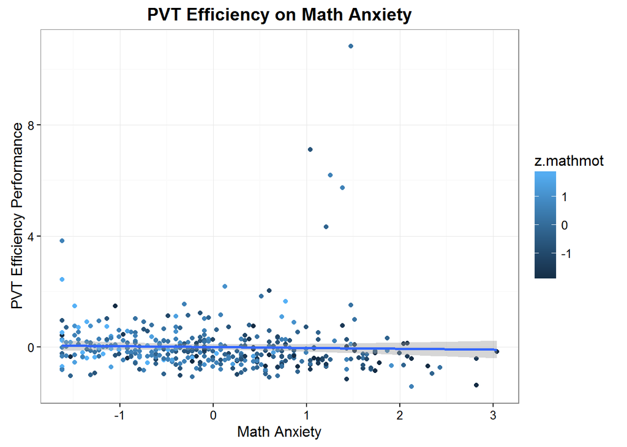

```r
#str(subjectmeans)
#head(subjectmeans)

ggplot(subjectmeans, aes(x = z.mathanx, y = z.pvt)) +
  geom_point(aes(color = z.mathmot)) +
  geom_smooth(method = lm) +
  xlab("Math Anxiety") +
  ylab("PVT Efficiency Performance") +
  ggtitle("PVT Efficiency on Math Anxiety") +
    theme(plot.title = element_text(lineheight=.8, face="bold"))
```

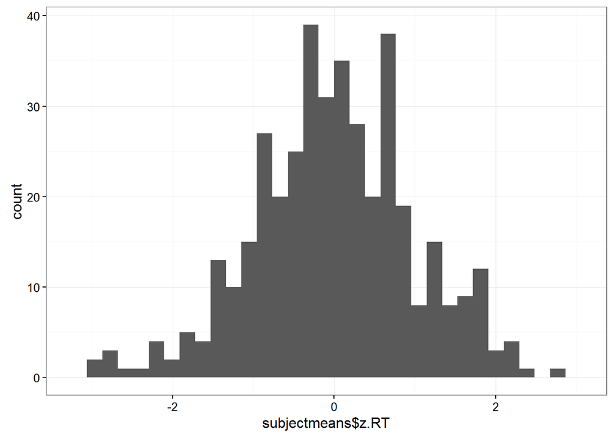

```r
qplot(subjectmeans$z.RT)
```

```r
sd(subjectmeans$mean.RT)
```

```
## [1] 1.259965
```

```r
mean(subjectmeans$mean.RT)
```

```
## [1] 4.108903
```

```r
z.toofast <- subjectmeans %>%
              filter(as.numeric(z.RT) <= -2.5)


subjectstokeep <- subjectmeans %>%
                  filter(as.numeric(z.RT) > -2.5)

subjectmeans <- subjectstokeep

z.pvthigh <- subjectmeans %>%
                filter(as.numeric(z.pvt) > 2)

#qplot(subjectmeans$mean.acc)
```

#### Confirmatory analysis

The analyses as specified in the analysis plan

```r
##NOTE -- this correlation chunk is not being evaluated yet because need at least 4 data points to run

#Script for generating clean correlation table (bottom triangle only) with significance stars
corstarsl <- function(x){
require(Hmisc)
x <- as.matrix(x)
R <- rcorr(x)$r
p <- rcorr(x)$P

## define notions for significance levels; spacing is important.
mystars <- ifelse(p < .001, "***", ifelse(p < .01, "** ", ifelse(p < .05, "* ", " ")))

## trunctuate the matrix that holds the correlations to two decimal
R <- format(round(cbind(rep(-1.11, ncol(x)), R), 2))[,-1]

## build a new matrix that includes the correlations with their apropriate stars
Rnew <- matrix(paste(R, mystars, sep=""), ncol=ncol(x))
diag(Rnew) <- paste(diag(R), " ", sep="")
rownames(Rnew) <- colnames(x)
colnames(Rnew) <- paste(colnames(x), "", sep="")

## remove upper triangle
Rnew <- as.matrix(Rnew)
Rnew[upper.tri(Rnew, diag = TRUE)] <- ""
Rnew <- as.data.frame(Rnew)

## remove last column and return the matrix (which is now a data frame)
Rnew <- cbind(Rnew[1:length(Rnew)-1])
return(Rnew)
}

##Create table from dataframe:
#cor_table <- corstarsl(corr.means)

##To remove unwanted columns from dataframe before adding to correlation table (in order to replicate table from original study)

cor.means <- subjectmeans %>%
  select_(.,'age', 'gender', 'mean.genanx', 'mean.mathanx', 'mean.mathmot', 'pvt')
cor.means$gender <- as.numeric(cor.means$gender)

##Create table from dataframe:
cor.confirm_table <- corstarsl(cor.means)

cor.confirm_table
```

```
##                   age   gender mean.genanx mean.mathanx mean.mathmot
## age
## gender       -0.14**
## mean.genanx  -0.22*** -0.14**
## mean.mathanx -0.17*** -0.14**      0.45***
## mean.mathmot    0.06   0.19***    -0.18***     -0.45***
## pvt             0.02     0.05       -0.06      -0.23***      0.16**
```

```r
## exporting tables to html, if desired:
#print.xtable(cor_table, type="html")
```

```r
#General Linear Models for Hierarchical Regression of Anxiety and Motivation on Performance

## Linear model with only gender, z.Math Anxiety, z.Math Motivation
mathperflm00 <- lm(z.pvt ~ gender + z.mathanx + z.mathmot, data = subjectmeans)

#Output nice knit table of model 00
#kable(summary(mathperflm00)$coef)

#Model 1 from study:  z.PVT Efficiency on Age, Gender, z.General Anx, z.General Anxiety squared
mathperflm1 <- lm(z.pvt ~ age + gender + z.genanx + I(z.genanx^2), data = subjectmeans)

#kable(summary(mathperflm1)$coef)


mathperflm2 <- lm(z.pvt ~ age + gender + z.genanx + I(z.genanx^2) + z.mathanx + z.mathmot, data = subjectmeans)

#kable(summary(mathperflm2)$coef)


mathperflm3 <- lm(z.pvt ~ age + gender + z.genanx + I(z.genanx^2) + z.mathanx + z.mathmot + I(z.mathanx^2) + z.mathanx * z.mathmot, data = subjectmeans)

#kable(summary(mathperflm3)$coef)


mathperflm4 <- lm(z.pvt ~ age + gender + z.genanx + I(z.genanx^2) + z.mathanx * z.mathmot + (I(z.mathanx^2) * z.mathmot), data = subjectmeans)

#kable(summary(mathperflm4)$coef)



##Alternatively, if the interaction terms don't already include those variables in the model
#mathperflm4.alt <- lm(z.pvt ~ age + gender + z.genanx + I(z.genanx^2) + z.mathanx + z.mathmot + I(z.mathanx^2) + (z.mathanx * z.mathmot) + (I(z.mathanx^2) * z.mathmot), data = subjectmeans)
#kable(summary(mathperflm4.alt)$coef)
```

## Key Model Replication Table

#### Summary table for replication of model. Model of note is Model 4, in which interaction between squared term of math anxiety and term for math motivation are included as predictors.

#### If Model 4 below demonstrates a significant increase to the predictive quality of the model by including the interaction term of anxiety^2 and motivation, then the findings from the MTurk sample will have replicated the findings from the original Wang et al. 2015 undergraduate sample.

#### This interaction term in Model 4 for the replication was not significant, thus the findings of Wang et al. (2015) did not replicate for this sample. Note, however, that the simple main effect of linear *math anxiety* is significantly predictive across models. See the Discussion section at the end of this report for a full discussion on these findings.

```r
mtable1234 <- mtable('Model 1' = mathperflm1,
            'Model 2' = mathperflm2,
            'Model 3' = mathperflm3,
            'Model 4' = mathperflm4,
            summary.stats= c("sigma","R-squared", "adj. R-squared", "F","p","N"),
            signif.symbols=getOption("signif.symbols"))

mtable1234
```

```
##
## Calls:
## Model 1: lm(formula = z.pvt ~ age + gender + z.genanx + I(z.genanx^2),
##     data = subjectmeans)
## Model 2: lm(formula = z.pvt ~ age + gender + z.genanx + I(z.genanx^2) +
##     z.mathanx + z.mathmot, data = subjectmeans)
## Model 3: lm(formula = z.pvt ~ age + gender + z.genanx + I(z.genanx^2) +
##     z.mathanx + z.mathmot + I(z.mathanx^2) + z.mathanx * z.mathmot,
##     data = subjectmeans)
## Model 4: lm(formula = z.pvt ~ age + gender + z.genanx + I(z.genanx^2) +
##     z.mathanx * z.mathmot + (I(z.mathanx^2) * z.mathmot), data = subjectmeans)
##
## ========================================================================
##                               Model 1   Model 2    Model 3    Model 4
## ------------------------------------------------------------------------
##   (Intercept)                  0.144    0.189      0.190      0.188
##                               (0.430)  (0.420)    (0.421)    (0.422)
##   age                          0.001   -0.000     -0.000     -0.000
##                               (0.003)  (0.003)    (0.003)    (0.003)
##   gender: female/decline      -0.294   -0.263     -0.270     -0.268
##                               (0.423)  (0.413)    (0.415)    (0.415)
##   gender: male/decline        -0.223   -0.233     -0.239     -0.237
##                               (0.423)  (0.414)    (0.415)    (0.416)
##   z.genanx                    -0.026    0.041      0.043      0.043
##                               (0.033)  (0.035)    (0.035)    (0.035)
##   I(z.genanx^2)               -0.013   -0.026     -0.028     -0.028
##                               (0.026)  (0.025)    (0.026)    (0.026)
##   z.mathanx                            -0.136***  -0.141***  -0.140***
##                                        (0.037)    (0.038)    (0.039)
##   z.mathmot                             0.040      0.040      0.037
##                                        (0.033)    (0.033)    (0.042)
##   I(z.mathanx^2)                                   0.003      0.004
##                                                   (0.029)    (0.030)
##   z.mathanx x z.mathmot                           -0.018     -0.018
##                                                   (0.031)    (0.032)
##   z.mathmot x I(z.mathanx^2)                                  0.002
##                                                              (0.023)
## ------------------------------------------------------------------------
##   sigma                          0.6       0.6        0.6        0.6
##   R-squared                      0.0       0.1        0.1        0.1
##   adj. R-squared                -0.0       0.0        0.0        0.0
##   F                              0.7       3.8        3.0        2.7
##   p                              0.6       0.0        0.0        0.0
##   N                            397       397        397        397
## ========================================================================
```

```r
#print(mtable123, file="mtabletest", format="HTML")
```

##### Below is the output table for the original 4-model comparison in Wang et al. (2015); note how the interaction term of math anxiety squared and math motivation adds predictive value to Model 4.

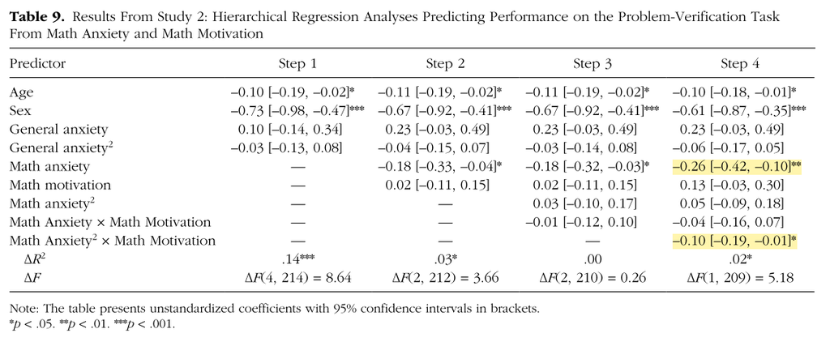

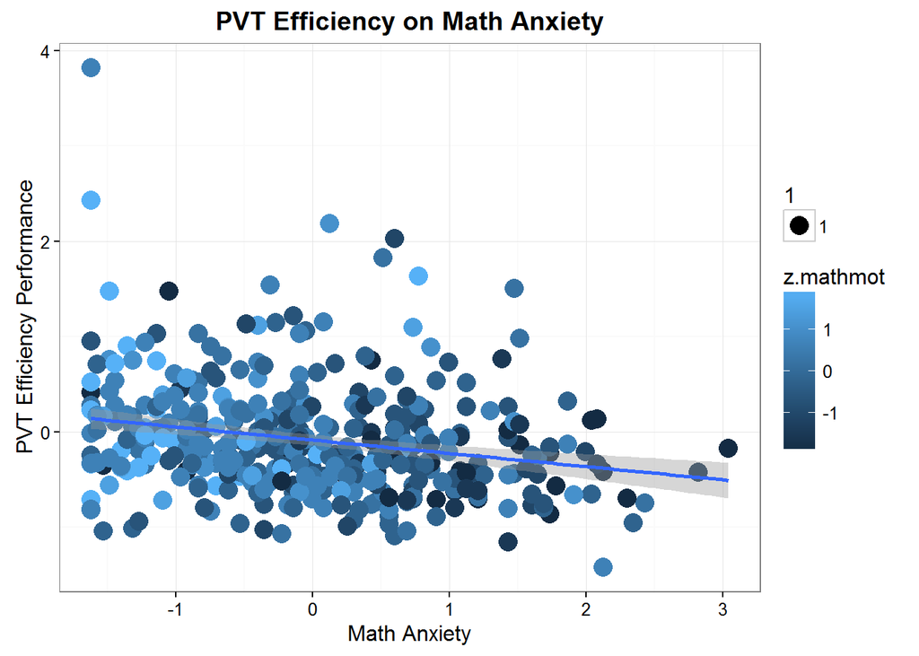

```r
ggplot(subjectmeans, aes(x = z.mathanx, y = z.pvt)) +
  geom_point(aes(color = z.mathmot, size = 1)) +
  geom_smooth(method = lm, data = mathperflm4) +
  xlab("Math Anxiety") +
  ylab("PVT Efficiency Performance") +
  ggtitle("PVT Efficiency on Math Anxiety") +
    theme(plot.title = element_text(lineheight=.8, face="bold"))
```

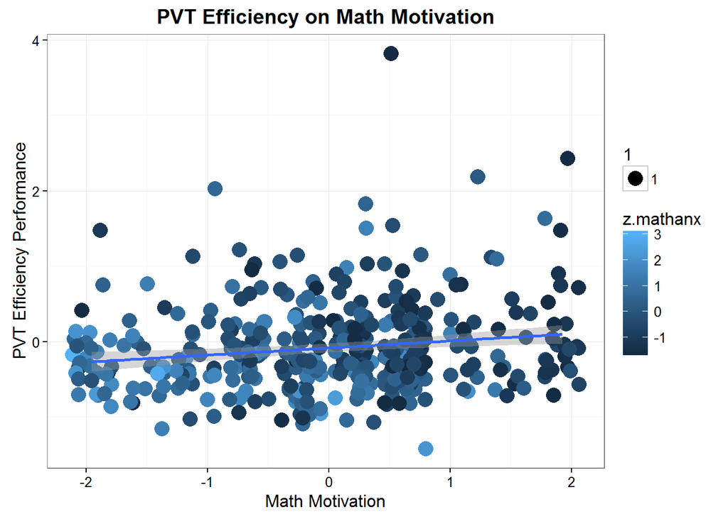

```r
ggplot(subjectmeans, aes(x = z.mathmot, y = z.pvt)) +
  geom_jitter(aes(color = z.mathanx, size = 1)) +
  geom_smooth(method = lm, data = mathperflm4) +
  xlab("Math Motivation") +
  ylab("PVT Efficiency Performance") +
  ggtitle("PVT Efficiency on Math Motivation") +
    theme(plot.title = element_text(lineheight=.8, face="bold"))
```

```r
## NOTE that both of these models are giving the same result b/c there is not (apparent) variation across math motivation according to the model

##Minus-1  gives  1 SD ABOVE b/c you are shifting the x axis "to the right" (mean becomes -1)

#mathanxmodel <- lm(z.pvt ~ z.mathanx, data = subjectmeans)
#kable(summary(mathanxmodel)$coef)

#predicts = as.data.frame(predict(mathanxmodel, type="resp"))
#predicts$mathanx <- subjectmeans$z.mathanx


mathperflm4_above <- lm(z.pvt ~ age + gender + z.genanx + I(z.genanx^2) + z.mathanx * I(z.mathmot - 1) + (I(z.mathanx^2) * I(z.mathmot - 1)), data = subjectmeans)

#kable(summary(mathperflm4_above)$coef)

mathperflm4_below <- lm(z.pvt ~ age + gender + z.genanx + I(z.genanx^2) + z.mathanx * I(z.mathmot + 1) + (I(z.mathanx^2) * I(z.mathmot + 1)), data = subjectmeans)

#kable(summary(mathperflm4_below)$coef)

# Find the linear model coefficients
above_lmcoefs <- coef(lm(z.pvt ~ age + gender + z.genanx + I(z.genanx^2) + z.mathanx * I(z.mathmot - 1) + (I(z.mathanx^2) * I(z.mathmot - 1)), data = subjectmeans))
#above_lmcoefs

below_lmcoefs <- coef(lm(z.pvt ~ age + gender + z.genanx + I(z.genanx^2) + z.mathanx * I(z.mathmot + 1) + (I(z.mathanx^2) * I(z.mathmot + 1)), data = subjectmeans))
#below_lmcoefs
# Create a function to produce the fitted line
above_lmeq <- function(x) above_lmcoefs[1] + above_lmcoefs[7] * x  + above_lmcoefs[9]*x^2
#above_lmeq

below_lmeq <- function(x) below_lmcoefs[1] + below_lmcoefs[7] * x  + above_lmcoefs[9]*x^2
#below_lmeq

###########################################

#mathperflm4_abovetest <- lm(z.pvt ~ age + gender + z.genanx + I(z.genanx^2) + (z.mathanx * I(z.mathmot)) + (I(z.mathanx^2) * I(z.mathmot)), data = subjectmeans)

#kable(summary(mathperflm4_abovetest)$coef)

#mathperflm4_belowtest <- lm(z.pvt ~ age + gender + z.genanx + I(z.genanx^2) + (z.mathanx * I(z.mathmot + 1)) + (I(z.mathanx^2) * I(z.mathmot + 1)), data = subjectmeans)

#kable(summary(mathperflm4_belowtest)$coef)

###########################################

mtable_abovebelow <- mtable('Model 1SD above' = mathperflm4_above,
            'Model 1SD below' = mathperflm4_below,
            summary.stats=c("R-squared", "N"),
            signif.symbols=getOption("signif.symbols"))

mtable_abovebelow
```

```
##
## Calls:
## Model 1SD above: lm(formula = z.pvt ~ age + gender + z.genanx + I(z.genanx^2) +
##     z.mathanx * I(z.mathmot - 1) + (I(z.mathanx^2) * I(z.mathmot -
##     1)), data = subjectmeans)
## Model 1SD below: lm(formula = z.pvt ~ age + gender + z.genanx + I(z.genanx^2) +
##     z.mathanx * I(z.mathmot + 1) + (I(z.mathanx^2) * I(z.mathmot +
##     1)), data = subjectmeans)
##
## =======================================================================
##                                      Model 1SD above  Model 1SD below
## -----------------------------------------------------------------------
##   (Intercept)                            0.225             0.151
##                                         (0.427)           (0.420)
##   age                                   -0.000            -0.000
##                                         (0.003)           (0.003)
##   gender: female/decline                -0.268            -0.268
##                                         (0.415)           (0.415)
##   gender: male/decline                  -0.237            -0.237
##                                         (0.416)           (0.416)
##   z.genanx                               0.043             0.043
##                                         (0.035)           (0.035)
##   I(z.genanx^2)                         -0.028            -0.028
##                                         (0.026)           (0.026)
##   z.mathanx                             -0.158**          -0.122*
##                                         (0.050)           (0.051)
##   I(z.mathmot - 1)                       0.037
##                                         (0.042)
##   I(z.mathanx^2)                         0.006             0.002
##                                         (0.043)           (0.032)
##   z.mathanx x I(z.mathmot - 1)          -0.018
##                                         (0.032)
##   I(z.mathmot - 1) x I(z.mathanx^2)      0.002
##                                         (0.023)
##   I(z.mathmot + 1)                                         0.037
##                                                           (0.042)
##   z.mathanx x I(z.mathmot + 1)                            -0.018
##                                                           (0.032)
##   I(z.mathmot + 1) x I(z.mathanx^2)                        0.002
##                                                           (0.023)
## -----------------------------------------------------------------------
##   R-squared                                0.1               0.1
##   N                                      397               397
## =======================================================================
```

```r
#print(mtable_abovebelow, format="HTML")
#summary(mathperflm4_above)

#predicts <- NA
#predicts <- as.data.frame(predicts)
#predicts <- data.frame(lm4abovepredicts=NA, lm4belowpredicts=NA)

#rm(predicts)
#predicts = as.data.frame(predict(mathperflm4_above, type="resp"))

#predicts$lm4belowpredicts <- predict(mathperflm4_below, type="resp")
#predicts$mathanx <- subjectmeans$z.mathanx
###########################################
#Testing different way to add model predictions
#subjectmeans$lm4abovepredictstest <- predict(mathperflm4_abovetest, type="resp")
#subjectmeans$lm4belowpredictstest <- predict(mathperflm4_belowtest, type="resp")
#summary(subjectmeans$lm4abovepredictstest)
#summary(subjectmeans$lm4belowpredictstest)
###########################################

#summary(subjectmeans$lm4abovepredicts)
#summary(subjectmeans$lm4belowpredicts)
```

### Predicted Model Plots

The generated figure below shows the model predictions for individuals at 1 SD above and 1 SD below in math motivation, using the replication data and following the format set in Figure 3 in the original.

The embedded figure below it (Figure 3) is from the original Wang et al. (2015).

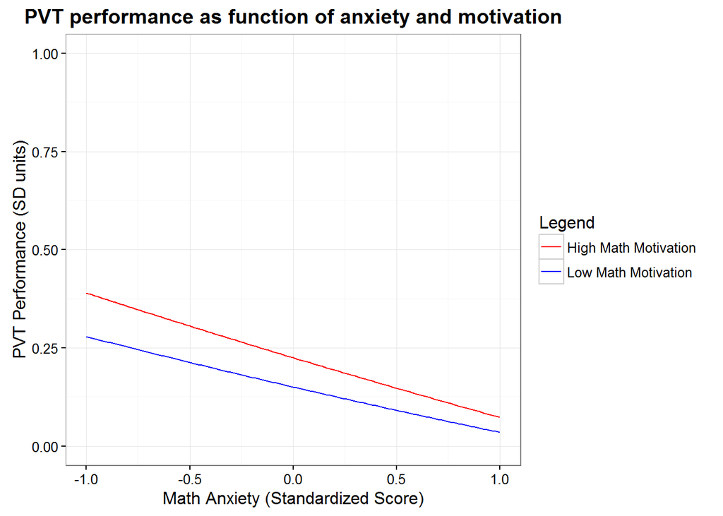

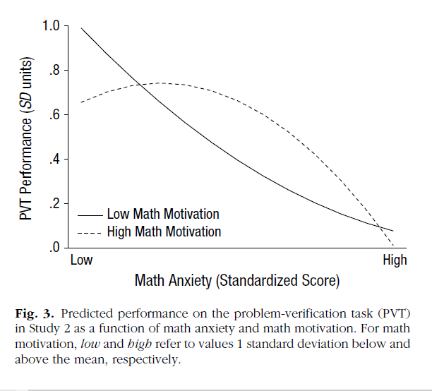

```r
##ggplot of two predicted lines: for models of motivation 1SD above and 1SD below
ggplot(subjectmeans, aes(x = z.mathanx, y = z.pvt)) +
  stat_function(fun = above_lmeq, aes(color = 'High Math Motivation')) +
  stat_function(fun = below_lmeq, aes(color = 'Low Math Motivation')) +
  scale_color_manual("Legend", values = c("red", "blue")) +
  xlab("Math Anxiety (Standardized Score)") +
  ylab("PVT Performance (SD units)") +
  ggtitle("PVT performance as function of anxiety and motivation") +
  theme(plot.title = element_text(lineheight=.8, face="bold")) +
  xlim(-1, 1) +
  ylim(0, 1)
```

For full clarity, below are the plotted predicted models alongside the replication data values, plotted for the full range of standard deviation units, rather than the -1 to 1 math anxiety and 0 to 1 math performance units, as done in the previous 2 figures.

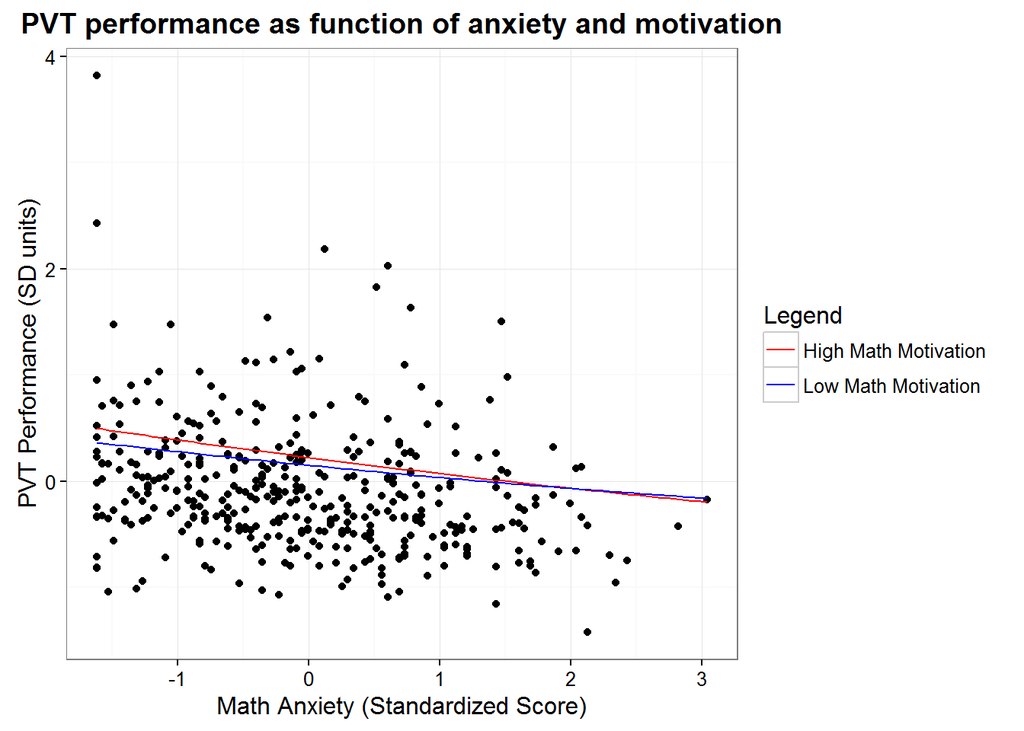

```r
##ggplot of two predicted lines: for models of motivation 1SD above and 1SD below
ggplot(subjectmeans, aes(x = z.mathanx, y = z.pvt)) +
 geom_point() +
  stat_function(fun = above_lmeq, aes(color = 'High Math Motivation')) +
  stat_function(fun = below_lmeq, aes(color = 'Low Math Motivation')) +
  scale_color_manual("Legend", values = c("red", "blue")) +
  xlab("Math Anxiety (Standardized Score)") +
  ylab("PVT Performance (SD units)") +
  ggtitle("PVT performance as function of anxiety and motivation") +
  theme(plot.title = element_text(lineheight=.8, face="bold")) #+
```

#### Exploratory analyses

- In addition to replicating the analyses conducted by the original study, this replication also intended to discern if any differences existed in the MTurk sample on math performance based on other potentially relevant predictors. Namely:
  - Level of education
  - Whether participant was currently a student
  - Number of school-aged (5 - 18 yrs) children
  - Self-described frequency with which participant “helped child with math homework”
  - Amount of time being a parent (age of oldest child)
- These exploratory analyses on effect of education level, current student status, whether or not participant has school-aged children, and frequency with which they help children with math homework on math performance will be conducted both independent of and in conjunction with math anxiety and math motivation. See below for planned analyses and plots of data.

```r
#### Mean Index and Standardized Scores for all measures  -- EXPLORATORY ANALYSES  #######
#str(d)
#Calculate mean
expsubmeans <- d %>%
  group_by(gender, education, student, children, ethnicity, race, children, mathhwhelp, childAgeOld, age, workerid) %>%
  summarise(mean.acc = mean(pvt.acc, na.rm=T),
            mean.RT = mean(sec.RT, na.rm=T),
            mean.mathmot = mean(mathmot, na.rm=T),
            mean.mathanx = mean(mathanx, na.rm=T),
            mean.genanx = mean(genanx, na.rm=T)) %>%
  mutate(pvt = (mean.acc*100) / mean.RT)


 #Generate z-scores for variables (using "scale" function)
expsubmeans$z.RT <- scale(expsubmeans$mean.RT, center = TRUE, scale = TRUE)
expsubmeans$z.pvt <- scale(expsubmeans$pvt, center = TRUE, scale = TRUE)
expsubmeans$z.mathmot <- scale(expsubmeans$mean.mathmot, center = TRUE, scale = TRUE)
expsubmeans$z.mathanx <- scale(expsubmeans$mean.mathanx, center = TRUE, scale = TRUE)
expsubmeans$z.genanx <- scale(expsubmeans$mean.genanx, center = TRUE, scale = TRUE)
```

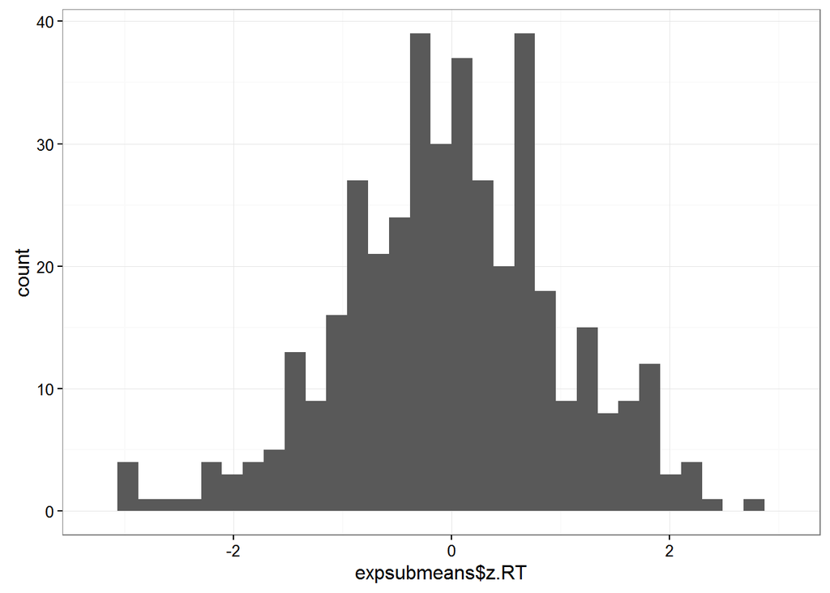

```r
#str(expsubmeans)
#head(expsubmeans)

require(dplyr)

qplot(expsubmeans$z.RT)
```

```r
#sd(expsubmeans$mean.RT)
#mean(expsubmeans$mean.RT)

#z.exptoofast <- expsubmeans %>%
 #             filter(as.numeric(z.RT) <= -2.5)

#class(expsubmeans$z.RT)
expsubjectstokeep <- expsubmeans %>%
                  filter(as.numeric(z.RT) > -2.5)

expsubmeans <- expsubjectstokeep

#qplot(subjectmeans$mean.acc)


expsubmeans$childAgeOld <- as.numeric(expsubmeans$childAgeOld)
expsubmeans$children <- as.numeric(expsubmeans$children)
expsubmeans$mathhwhelp <- as.numeric(expsubmeans$mathhwhelp)
```

```r
#Prep exploratory data to run through table:
cor.explore.means <- expsubmeans %>%
  select_(.,'age', 'gender', 'education', 'student', 'ethnicity', 'race', 'children', 'mathhwhelp', 'childAgeOld', 'mean.genanx', 'mean.mathanx', 'mean.mathmot', 'pvt')

cor.explore.means$gender <- as.numeric(cor.explore.means$gender)
cor.explore.means$education <- as.numeric(as.factor(cor.explore.means$education))
cor.explore.means$student <- as.numeric(as.factor(cor.explore.means$student))
cor.explore.means$ethnicity <- as.numeric(as.factor(cor.explore.means$ethnicity))
cor.explore.means$race <- as.numeric(cor.explore.means$race)
cor.explore.means$children <- as.numeric(cor.explore.means$children)
cor.explore.means$mathhwhelp <- as.numeric(cor.explore.means$mathhwhelp)
cor.explore.means$childAgeOld <- as.numeric(cor.explore.means$childAgeOld)

#str(cor.explore.means)
##Create table from dataframe:
cor.explore_table <- corstarsl(cor.explore.means)

cor.explore_table
```

```
##                   age   gender education student ethnicity   race children
## age
## gender       -0.15**
## education       0.02    -0.01
## student      -0.30***    0.06    0.17***
## ethnicity       0.02     0.05     -0.03   -0.03
## race          0.15**     0.04    0.13**  -0.11*     -0.01
## children        0.06  -0.19***     0.04   -0.09   -0.14**   0.06
## mathhwhelp     -0.06     0.05      0.00    0.07      0.00   0.00   0.27***
## childAgeOld     0.07    0.11*      0.01   -0.01     0.11*  -0.09  -0.36***
## mean.genanx  -0.22*** -0.14**      0.04    0.04     -0.01  -0.09     0.01
## mean.mathanx -0.17*** -0.14**      0.01    0.05      0.00  -0.10     0.00
## mean.mathmot    0.06   0.18***    -0.07   -0.01      0.08   0.00    -0.05
## pvt             0.02     0.05     -0.05    0.01      0.10   0.00    -0.02
##              mathhwhelp childAgeOld mean.genanx mean.mathanx mean.mathmot
## age
## gender
## education
## student
## ethnicity
## race
## children
## mathhwhelp
## childAgeOld      0.11*
## mean.genanx       0.03       -0.05
## mean.mathanx      0.01        0.00      0.45***
## mean.mathmot     -0.05       -0.01     -0.17***     -0.45***
## pvt               0.01        0.08       -0.06      -0.23***      0.16**
```

```r
#Linear Model for Anxiety and Motivation, with Education and Children variables included:

## Linear model with only gender, z.Math Anxiety, z.Math Motivation
exploreperflm00 <- lm(z.pvt ~ gender + z.mathanx + z.mathmot, data = expsubmeans)

#Output nice knit table of model 00
#kable(summary(exploreperflm00)$coef)
#Note this should be the same output as model 00 from above (same variables, same analysis)


#Additional models with just demographic info:
exploreperflm.a <- lm(z.pvt ~ age + gender + student + education + children + mathhwhelp + childAgeOld, data = expsubmeans)
#kable(summary(exploreperflm.a)$coef)


######################################


#Model 1 from study with additional demographics:  z.PVT Efficiency on Age, Gender, Student status, education, z.General Anx, z.Math Anx
exploreperflm1 <- lm(z.pvt ~ age + gender + student + education + children + mathhwhelp + z.genanx + z.mathanx, data = expsubmeans)

#kable(summary(exploreperflm1)$coef)

#Model 2 from study with additonal demographics:
exploreperflm2 <- lm(z.pvt ~ age + gender + student + education + children + mathhwhelp + z.genanx + I(z.genanx^2) + z.mathanx + z.mathmot, data = expsubmeans)

#kable(summary(exploreperflm2)$coef)

#Model 3 from study with additonal demographics:
exploreperflm3 <- lm(z.pvt ~ age + gender+ student + education + children + mathhwhelp + z.genanx + I(z.genanx^2) + z.mathanx + z.mathmot + I(z.mathanx^2) + z.mathanx * z.mathmot, data = expsubmeans)

#kable(summary(exploreperflm3)$coef)

#Model 4 from study with additonal demographics:
exploreperflm4 <- lm(z.pvt ~ age + gender + student + education + children + mathhwhelp + z.genanx + I(z.genanx^2) + z.mathanx * z.mathmot + (I(z.mathanx^2) * z.mathmot), data = expsubmeans)
#kable(summary(exploreperflm4)$coef)
#summary(exploreperflm4)
```

```r
mtable.explore <- mtable('Model 1' = exploreperflm1,
            'Model 2' = exploreperflm2,
            'Model 3' = exploreperflm3,
            'Model 4' = exploreperflm4,
            summary.stats=T,
            signif.symbols=getOption("signif.symbols"))

mtable.explore
```

```
##
## Calls:
## Model 1: lm(formula = z.pvt ~ age + gender + student + education + children +
##     mathhwhelp + z.genanx + z.mathanx, data = expsubmeans)
## Model 2: lm(formula = z.pvt ~ age + gender + student + education + children +
##     mathhwhelp + z.genanx + I(z.genanx^2) + z.mathanx + z.mathmot,
##     data = expsubmeans)
## Model 3: lm(formula = z.pvt ~ age + gender + student + education + children +
##     mathhwhelp + z.genanx + I(z.genanx^2) + z.mathanx + z.mathmot +
##     I(z.mathanx^2) + z.mathanx * z.mathmot, data = expsubmeans)
## Model 4: lm(formula = z.pvt ~ age + gender + student + education + children +
##     mathhwhelp + z.genanx + I(z.genanx^2) + z.mathanx * z.mathmot +
##     (I(z.mathanx^2) * z.mathmot), data = expsubmeans)
##
## ==========================================================================
##                                Model 1    Model 2    Model 3    Model 4
## --------------------------------------------------------------------------
##   (Intercept)                  0.239      0.262      0.269      0.268
##                               (0.548)    (0.549)    (0.550)    (0.551)
##   age                          0.001      0.001      0.001      0.001
##                               (0.003)    (0.003)    (0.003)    (0.003)
##   gender: female/decline      -0.420     -0.419     -0.410     -0.410
##                               (0.641)    (0.641)    (0.643)    (0.643)
##   gender: male/decline        -0.389     -0.395     -0.385     -0.384
##                               (0.639)    (0.640)    (0.641)    (0.642)
##   student: decline             0.138      0.172      0.181      0.181
##                               (0.521)    (0.522)    (0.523)    (0.524)
##   student: no                 -0.176     -0.183     -0.185     -0.185
##                               (0.204)    (0.205)    (0.206)    (0.206)
##   student: yes                -0.019     -0.033     -0.036     -0.036
##                               (0.218)    (0.219)    (0.220)    (0.220)
##   education: 4year/            0.245      0.242      0.222      0.222
##                               (0.431)    (0.432)    (0.433)    (0.434)
##   education: Grad/             0.380      0.370      0.357      0.358
##                               (0.435)    (0.436)    (0.437)    (0.438)
##   education: highSchool/       0.129      0.132      0.113      0.113
##                               (0.440)    (0.440)    (0.442)    (0.443)
##   education: someCollege/      0.168      0.171      0.155      0.155
##                               (0.429)    (0.429)    (0.431)    (0.431)
##   education: someGrad/         0.139      0.140      0.122      0.122
```

[output cut: 16 more lines]

```
##                                                     (0.032)    (0.032)
##   z.mathmot x I(z.mathanx^2)                                    0.001
##                                                                (0.023)
## --------------------------------------------------------------------------
##   R-squared                       0.1        0.1        0.1        0.1
##   adj. R-squared                  0.0        0.0        0.0        0.0
##   sigma                           0.6        0.6        0.6        0.6
##   F                               2.3        2.1        1.9        1.8
##   p                               0.0        0.0        0.0        0.0
##   Log-likelihood               -340.6     -339.7     -339.4     -339.4
##   Deviance                      128.8      128.2      128.0      128.0
##   AIC                           715.3      717.4      720.8      722.8
##   BIC                           783.1      793.1      804.5      810.5
##   N                             399        399        399        399
## ==========================================================================
```

```r
#print(mtable.explore, file="mtableexplore", format="HTML")
```

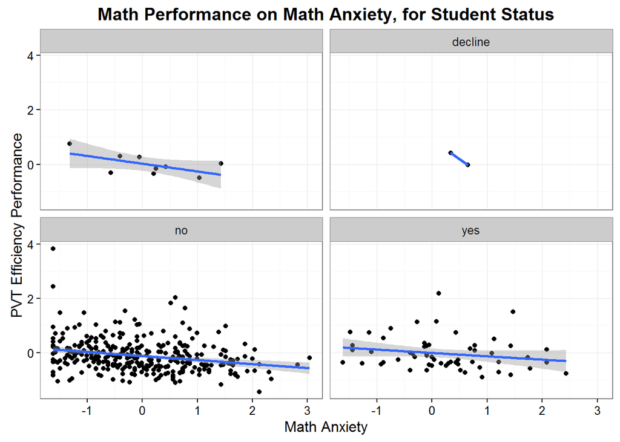

```r
#Math Performance regressed on math anxiety, facetted by whether or not participant was currently a student:

ggplot(expsubmeans, aes(x = z.mathanx, y = z.pvt)) +
  geom_point() +
  geom_smooth(method = lm, data = expsubmeans) +
  xlab("Math Anxiety") +
  ylab("PVT Efficiency Performance") +
  ggtitle("Math Performance on Math Anxiety, for Student Status") +
    theme(plot.title = element_text(lineheight=.8, face="bold")) +
  facet_wrap(~student)
```

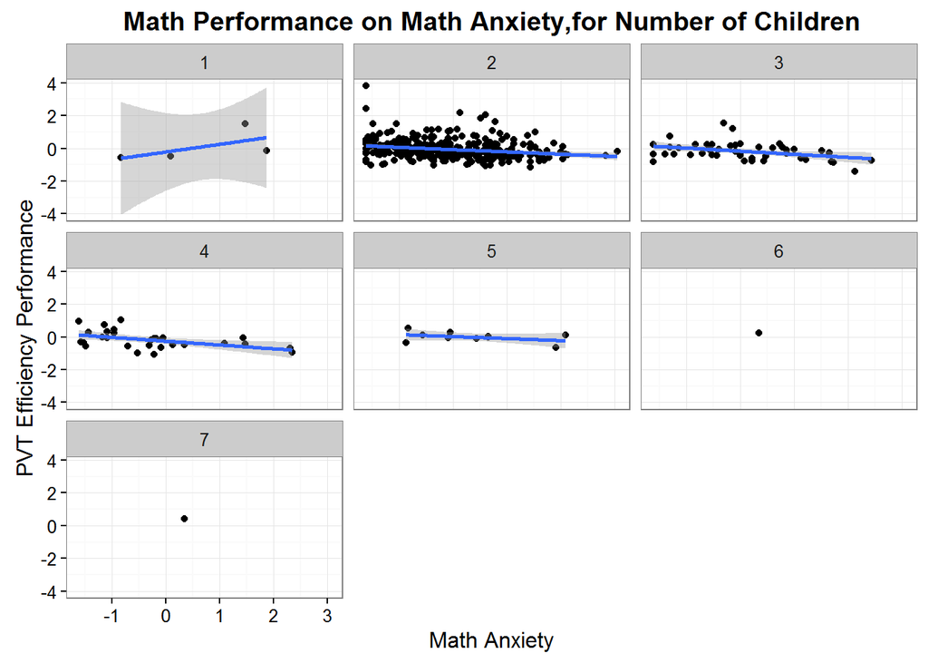

```r
#Math Performance regressed on math anxiety, facetted by whether or not participant has school-aged children:
ggplot(expsubmeans, aes(x = z.mathanx, y = z.pvt)) +
  geom_point() +
  geom_smooth(method = lm, data = expsubmeans) +
  xlab("Math Anxiety") +
  ylab("PVT Efficiency Performance") +
  ggtitle("Math Performance on Math Anxiety,for Number of Children") +
  theme(plot.title = element_text(lineheight=.8, face="bold")) +
  facet_wrap(~children)
```

```r
## NOTE that both of these models are giving the same result b/c there is not (apparent) variation across math motivation according to the model

##Minus-1  gives  1 SD ABOVE b/c you are shifting the x axis "to the right" (mean becomes -1)

#class(expsubmeans$children)



mathperflm4.explore_above <- lm(z.pvt ~ age + gender + children + childAgeOld + mathhwhelp + z.genanx + I(z.genanx^2) + z.mathanx * I(z.mathmot - 1) + (I(z.mathanx^2) * I(z.mathmot - 1)), data = expsubmeans)

#kable(summary(mathperflm4.explore_above)$coef)



mathperflm4.explore_below <- lm(z.pvt ~ age + gender + children + childAgeOld + mathhwhelp + z.genanx + I(z.genanx^2) + z.mathanx * I(z.mathmot + 1) + (I(z.mathanx^2) * I(z.mathmot + 1)), data = expsubmeans)

#kable(summary(mathperflm4.explore_below)$coef)
```

### (Post Data Collection) Methods Addendum

#### Actual Sample

The collected sample size was 415 MTurk participants. From this sample, 12 participants were excluded from the analyses due to unresolvable corruptions in the data files, and 6 were excluded due to random answers or non-compliance (see “Excluding Outliers” section, above). The total sample size used for analyses was thus *397* participants, which satisfies the participant goal for achieving 80% power.

#### Differences from pre-data collection methods plan

No operational changes were made from the pre-data collection methods plan. Some adjustments were made to the method by which the ggplot of the predicted models was created, but the model itself was the same as that outlined in the data plan.

### Results

Below is a quoted excerpt from the original text (emphasis added), describing the key results obtained from the hierarchical linear models conducted on the data. Note that after controlling for their covariates of interest, and linear and two-way interaction effects, the quadratic interaction between math anxiety and math motivation added predictive effects on math performance.

> Overall, age and sex both negatively predicted task performance, which indicates that younger and male participants performed better on average than older and female participants, with a larger effect size for sex than for age. General anxiety did not predict math performance. Math anxiety negatively predicted math performance after we controlled for the effects of the covariates. Finally, after controlling for all the linear and two-way interaction effects, we found that *the moderated quadratic interaction between math anxiety and math motivation was statistically significant and added incremental predictive effects on math performance*.

The current study did not replicate the key finding of Wang et al. (2015), in that the interaction term of *math anxiety squared* and *math motivation* did not add significant predictive value to the model of math performance. In the original study, this interaction coefficient had a value of *-.10* (standardized units) and was significant at *p*<.05. In the current replication, this same coefficient had a value of *0.002* and a p-value of *0.923*.

Of note, the linear main effect term for math anxiety was significantly predictive, and was so across all relevant tested models. In Model 4, math anxiety had a coefficient of *-0.140* and was significant at *p*=.00039. This relationship can be seen by the fact that the plotted models all show a consistent linear decrease in math performance as math anxiety levels among individuals became higher.

This main effect of math anxiety was also the only term that remained significantly predictive when all demographic covariates were included in the regression models. In Model 4 of the exploratory analyses, math anxiety had a coefficient of *-0.141* and was significant at *p*=.00042.

### Discussion

#### Summary of Replication Attempt

As mentioned above, the primary result from the confirmatory analysis did not replicate the significant findings of Wang et al. (2015). A significant main effect of math anxiety on math performance was found, in that there is a negative predictive relationship between math anxiety and math performance. But the finding that math anxiety has different effects on math performance depending on math motivation was not found. As such, though a stable pattern between math anxiety and math performance was found, because no main effects of math motivation or interactions between motivation or anxiety were found, the current study failed to replicate original results.

#### Commentary

Exploratory analyses attempted to discern if the relationship between math anxiety and math performance was differentially affected by relevant demographic characteristics of the MTurk population. None of the predictors included in a number of models significantly altered or improved the model of the relationship between anxiety and performance. Math anxiety remained significantly negatively predictive of math performance across a number of demographic characteristics, including the education level of participants, whether or not the participant was currently a student, and whether the participant had children and helped their children with math homework.